# Lab Data Visualization with R Package ggplot2 part I

## Aesthetic Mappings - 1

The aesthetic mappings allow to select variables to be plotted and use data properties to influence visual characteristics such as color, size, shape, position, etc. As a result, each visual characteristic can encode a different part of the data and be utilized to communicate information.

All aesthetics for a plot are specified in the aes() function call.

For example, we can add a mapping from the class of the cars to a color characteristic:

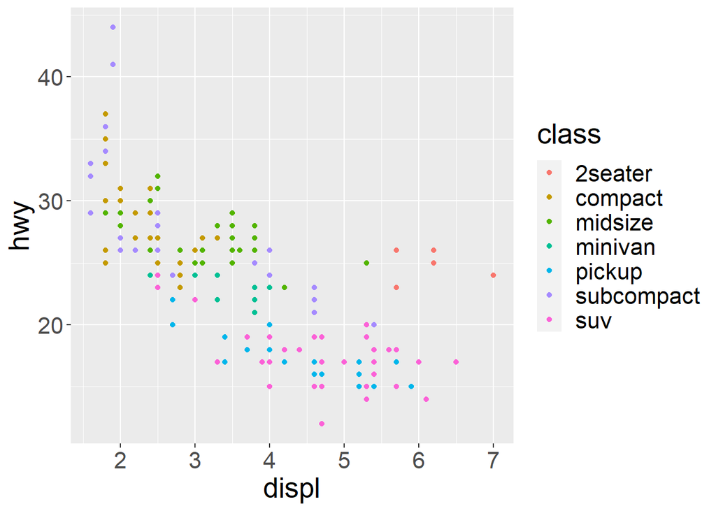

```r
ggplot(mpg,
       aes(x = displ, y = hwy, color = class)) +
  geom_point() +
  theme(text = element_text(size = 20))
```

## Aesthetic Mappings - 2

**Note:**

If we wish to apply an aesthetic property to an entire geometry, you can set that property as an argument to the geom method, outside of the aes() call:

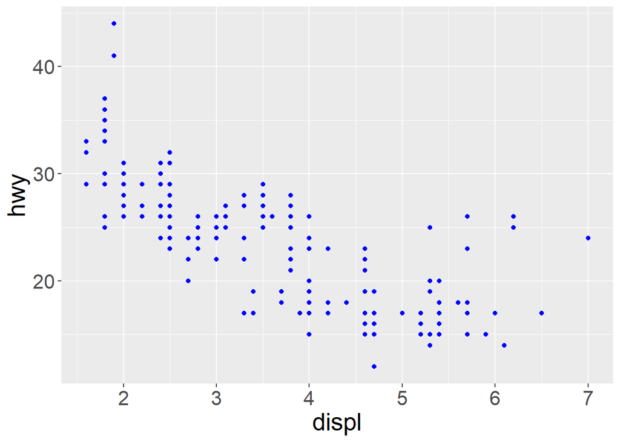

```r
ggplot(mpg,
       aes(x = displ, y = hwy)) +
  geom_point(color = "blue")  +
  theme(text = element_text(size = 20))
```

## Specifying Geometric Shapes - 1

Building on these basics, we can use ggplot2 to create almost any kind of plot we may want. These plots are declared using functions that follow from the Grammar of Graphics. ggplot2 supports a number of different types of geometric objects, including:

- geom_bar(): bar charts  
- geom_boxplot(): boxplots  
- geom_histogram(): histograms  
- geom_line(): lines  
- geom_map(): polygons in the shape of a map.  
- geom_point(): individual points  
- geom_polygon(): arbitrary shapes  
- geom_smooth(): smoothed lines

Each of these geometries will make use of the aesthetic mappings provided, albeit the visual qualities to which the data will be mapped will differ. For example, we can map data to the shape of a geom_point (e.g., if they should be circles or squares), or we can map data to the line-type of a geom_line (e.g., if it is solid or dotted), but not vice versa.

Almost all geoms require an x and y mapping at the bare minimum.